# Capstone Study DAC8 - Cyclistic

Keith Murray

Last Updated: 07 September, 2021

# 1 Overview of Task

## 1.1 Guiding Questions:

How do annual members and casual riders use Cyclistic bikes differently?

Which casual users are more likely to convert to annual memberships?

## 1.2 Business Task:

Uncover key differences between annual member and casual rider bike use.

## 1.3 Deliverable:

Identify the top three differences in bike use between annual members and casual bike users

# 2 Preparation of Data

## 2.1 READING IN DATA

```r
csv_list<-dir(here("Data"),pattern=".csv")
cycle_data = tibble()
for(i in 1:length(csv_list)){
  df <- read_csv(paste(here("Data",csv_list[i])))
  cycle_data <- rbind(cycle_data,df)
}

##Factorising month and day of week
month_levels <- c(1,2,3,4,5,6,7,8,9,10,11,12)
day_of_week_levels <- c("Monday", "Tuesday", "Wednesday", "Thursday", "Friday", "Saturday", "Sunday")

###Creating new variables
cycle_data2 <- cycle_data %>%
  mutate(cy_year_month = started_at%>%format("%Y-%m"),
         cy_year = started_at%>%format("%Y")%>%as.numeric(),
         ##attempt at factorisation month
         cy_month = started_at %>%format("%m")%>%as.numeric()%>%factor(levels = month_levels),
         cy_day = started_at %>% format("%d") %>% as.numeric(),
         ##attempt at factorisation day_of_week
         cy_day_of_week = started_at %>% weekdays() %>% factor(levels = day_of_week_levels),
         cy_iso_week = started_at %>% isoweek() %>% as.numeric(),
         cy_time_m = difftime(ended_at,started_at,units="mins"),
         cy_distance_m = distHaversine(cbind(start_lng,start_lat),cbind(end_lng,end_lat)))

##The dataset is large so I remove the original, as well as other unnecessary objects
rm(list = c("csv_list","cycle_data","df","i","month_levels","day_of_week_levels"))
```

### 2.1.1 Overview of read-in data

```
## ── Data Summary ────────────────────────
##                            Values
## Name                       data
## Number of rows             5910616
## Number of columns          21
## _______________________
## Column type frequency:
##   character                8
##   difftime                 1
##   factor                   2
##   numeric                  8
##   POSIXct                  2
## ________________________
## Group variables            None
##
## ── Variable type: character ──────────────────────────────────────────────────────────────────────────────────
##   skim_variable      n_missing complete_rate   min   max empty n_unique whitespace
## 1 ride_id                    0         1        16    16     0  5910407          0
## 2 rideable_type              0         1        11    13     0        3          0
## 3 start_station_name    369331         0.938    10    53     0      749          0
## 4 start_station_id      369956         0.937     1    36     0     1287          0
## 5 end_station_name      409155         0.931    10    53     0      746          0
## 6 end_station_id        409616         0.931     1    36     0     1286          0
## 7 member_casual              0         1         6     6     0        2          0
## 8 cy_year_month              0         1         7     7     0       16          0
##
## ── Variable type: difftime ───────────────────────────────────────────────────────────────────────────────────
##   skim_variable n_missing complete_rate min            max           median        n_unique
## 1 cy_time_m             0             1 -29049.97 mins 58720.03 mins 14.03333 mins    31619
##
## ── Variable type: factor ─────────────────────────────────────────────────────────────────────────────────────
##   skim_variable  n_missing complete_rate ordered n_unique top_counts
## 1 cy_month               0             1 FALSE         12 7: 1373890, 6: 1072600, 5: 731907, 8: 622361
## 2 cy_day_of_week         0             1 FALSE          7 Sat: 1111642, Sun: 906979, Fri: 878575, Thu: 779042
##
## ── Variable type: numeric ────────────────────────────────────────────────────────────────────────────────────
##   skim_variable n_missing complete_rate   mean        sd     p0    p25    p50    p75    p100 hist
## 1 start_lat             0         1       41.9    0.0437   41.6   41.9   41.9   41.9    42.1 ▁▁▇▇▁
## 2 start_lng             0         1      -87.6    0.0261  -87.9  -87.7  -87.6  -87.6   -87.5 ▁▁▂▇▁
## 3 end_lat            6905         0.999   41.9    0.0438   41.5   41.9   41.9   41.9    42.2 ▁▁▇▇▁
## 4 end_lng            6905         0.999  -87.6    0.0263  -88.1  -87.7  -87.6  -87.6   -87.4 ▁▁▁▇▁
## 5 cy_year               0         1     2020.     0.499  2020   2020   2020   2021    2021   ▇▁▁▁▇
## 6 cy_day                0         1       15.9    8.80      1      8     16     23      31   ▇▇▇▇▆
## 7 cy_iso_week           0         1       27.9   10.0       1     22     27     35      53   ▁▃▇▃▂
## 8 cy_distance_m      6905         0.999 2234.  2022.        0    879.  1696.  3031.  48425.  ▇▁▁▁▁
##
## ── Variable type: POSIXct ────────────────────────────────────────────────────────────────────────────────────
##   skim_variable n_missing complete_rate min                 max                 median              n_unique
## 1 started_at            0             1 2020-04-01 00:00:30 2021-07-31 23:59:58 2020-11-25 11:10:06  5035619
## 2 ended_at              0             1 2020-04-01 00:10:45 2021-08-12 17:45:41 2020-11-25 10:46:32  5021291
```

## 2.2 CLEANING DATA

### 2.2.1 First, I remove duplicates

```r
##getting record of rows before duplicates are removed
number_of_rows_before <- nrow(cycle_data2)
cycle_data2 <- cycle_data2%>%distinct(ride_id, .keep_all = TRUE)
```

Checking that this has been successful:

```
## No. rows before duplicates removed: 5910616
##  No. rows after duplicates removed: 5910407
##  No. duplicate rows removed: 209
```

### 2.2.2 Then I remove NA values from end_lat/end_long columns

```r
num_NAs_end_lat <- cycle_data2 %>% filter(is.na(end_lat))%>%nrow()
cycle_data2 <- cycle_data2 %>% filter(!is.na(end_lat))
```

```
## Number of rows to be dropped: 6904
##  Number of NA values in end_lat after drop: 0
##  Number of NA values in end_lng after drop: 0
##  Number of NA values in distance_m after drop: 0
```

### 2.2.3 There are negative values for the times the cycles are used. This is clearly an error, but I need to check how prevalent it is.

#### 2.2.3.1 I use a boxplot to get a feel for this data.

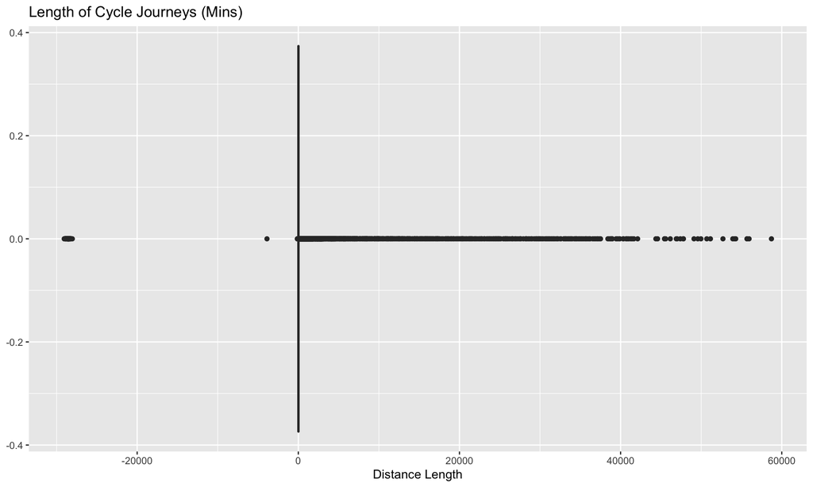

```r
cycle_data2 %>% ggplot() +
  geom_boxplot(aes(x=cy_time_m))+
  labs(title='Length of Cycle Journeys (Mins)',x='Distance Length')
```

This graph shows that the vast majority of values are close to zero, and that we have a lot of positive outliers and a small amount of xtremely negative outliers. At a resolution of 24 hours, the spread is outlined in the table below:

| class_days | number_trips | percent_of_total_trips |
| --- | --- | --- |
| <0 | 10343 | 0.17520106 |
| 0-1d | 5890168 | 99.77411716 |
| 1-3d | 1972 | 0.03340390 |
| 4+ | 1020 | 0.01727788 |

As was clear from the boxplot, the vast majority of trips are less than 24 hours long. The negative times comprise less than .5% of the total, so I assume that dropping them will not have a major impact on results.

#### 2.2.3.2 I drop the negative times from the main dataset, saving them if needed for later.

```r
negative_times <- cycle_data2 %>% filter(cy_time_m <0)
cycle_data2 <- cycle_data2 %>% filter(cy_time_m >= 0)
```

### 2.2.4 Final check for cycle_data2

```
## ── Data Summary ────────────────────────
##                            Values
## Name                       data
## Number of rows             5893160
## Number of columns          21
## _______________________
## Column type frequency:
##   character                8
##   difftime                 1
##   factor                   2
##   numeric                  8
##   POSIXct                  2
## ________________________
## Group variables            None
##
## ── Variable type: character ──────────────────────────────────────────────────────────────────────────────────
##   skim_variable      n_missing complete_rate   min   max empty n_unique whitespace
## 1 ride_id                    0             1    16    16     0  5893160          0
## 2 rideable_type              0             1    11    13     0        3          0
## 3 start_station_name         0             1     7    53     0      750          0
## 4 start_station_id           0             1     1    36     0     1288          0
## 5 end_station_name           0             1     7    53     0      747          0
## 6 end_station_id             0             1     1    36     0     1287          0
## 7 member_casual              0             1     6     6     0        2          0
## 8 cy_year_month              0             1     7     7     0       16          0
##
## ── Variable type: difftime ───────────────────────────────────────────────────────────────────────────────────
##   skim_variable n_missing complete_rate min    max           median        n_unique
## 1 cy_time_m             0             1 0 mins 58720.03 mins 14.03333 mins    30047
##
## ── Variable type: factor ─────────────────────────────────────────────────────────────────────────────────────
##   skim_variable  n_missing complete_rate ordered n_unique top_counts
## 1 cy_month               0             1 FALSE         12 7: 1370632, 6: 1070942, 5: 730961, 8: 618659
## 2 cy_day_of_week         0             1 FALSE          7 Sat: 1108358, Sun: 904312, Fri: 875729, Thu: 776920
##
## ── Variable type: numeric ────────────────────────────────────────────────────────────────────────────────────
##   skim_variable n_missing complete_rate   mean        sd     p0    p25    p50    p75    p100 hist
## 1 start_lat             0             1   41.9    0.0437   41.6   41.9   41.9   41.9    42.1 ▁▁▇▇▁
## 2 start_lng             0             1  -87.6    0.0261  -87.9  -87.7  -87.6  -87.6   -87.5 ▁▁▂▇▁
## 3 end_lat               0             1   41.9    0.0438   41.5   41.9   41.9   41.9    42.2 ▁▁▇▇▁
## 4 end_lng               0             1  -87.6    0.0263  -88.1  -87.7  -87.6  -87.6   -87.4 ▁▁▁▇▁
## 5 cy_year               0             1 2020.     0.499  2020   2020   2020   2021    2021   ▇▁▁▁▇
## 6 cy_day                0             1   15.9    8.80      1      8     16     23      31   ▇▇▇▇▆
## 7 cy_iso_week           0             1   27.9   10.0       1     22     27     34      53   ▁▃▇▃▂
## 8 cy_distance_m         0             1 2234.  2022.        0    879.  1696.  3030.  48425.  ▇▁▁▁▁
##
## ── Variable type: POSIXct ────────────────────────────────────────────────────────────────────────────────────
##   skim_variable n_missing complete_rate min                 max                 median              n_unique
## 1 started_at            0             1 2020-04-01 00:00:30 2021-07-31 23:59:58 2020-11-26 17:57:46  5025638
## 2 ended_at              0             1 2020-04-01 00:10:45 2021-08-12 17:45:41 2020-11-26 18:15:45  5008793
```

# 3 Analysis

## 3.1 Median time and distance spent on bicycles

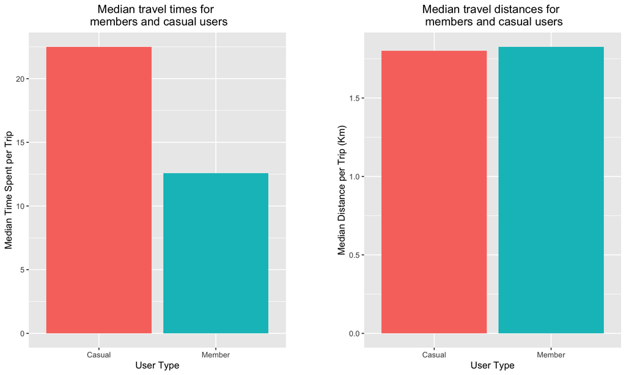

Both casual users and members typically travel ~ 1.75 kms per trip; however casual users travel ~ 10 minutes longer than members.

## 3.2 Rideable proportions by user type

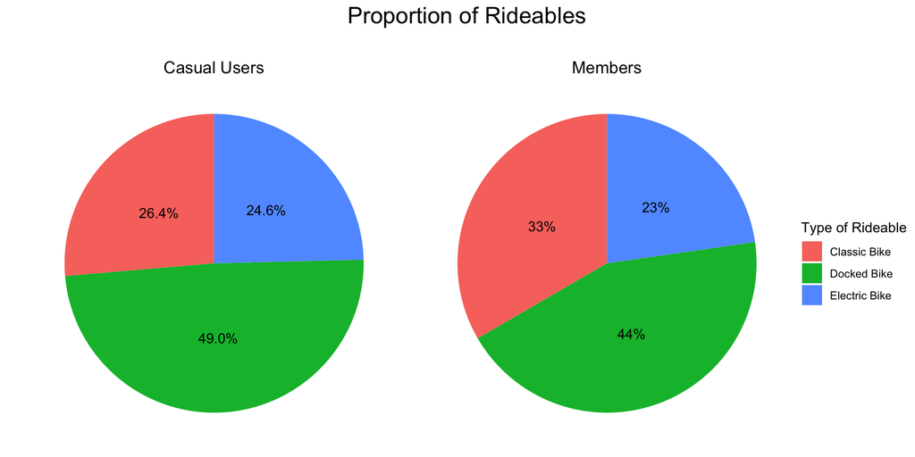

- Both user groups use roughly the same proportion of bicycle types.
- Members use slightly more classic bike types than casual users, who favour docked bikes.

## 3.3 Monthly / Annual user trends

### 3.3.1 First we check how the time of year influences bike use for members and casual users

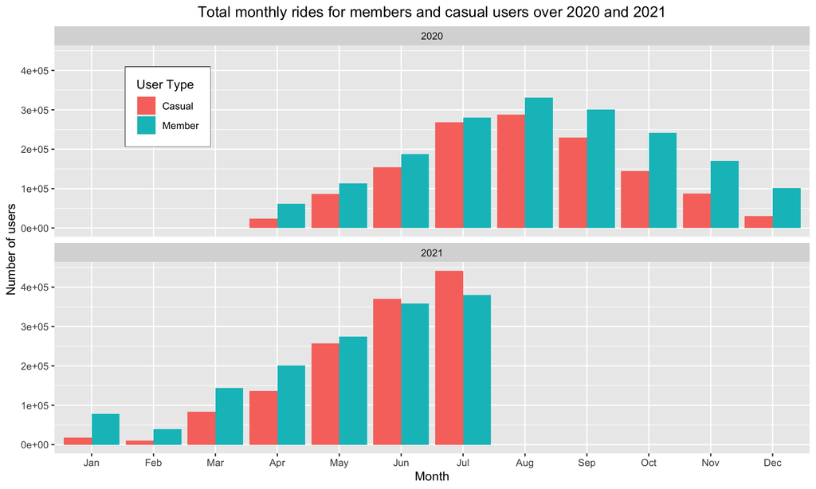

#### 3.3.1.1 Time of year takeaways

- Bicycle rental more prevelant in summer months.
- Members more likely to rent bikes, particularly in winter months.
- In 2021, more casual users than members in over summer months June and July

#### 3.3.1.2 Growth comparison for consecutive months

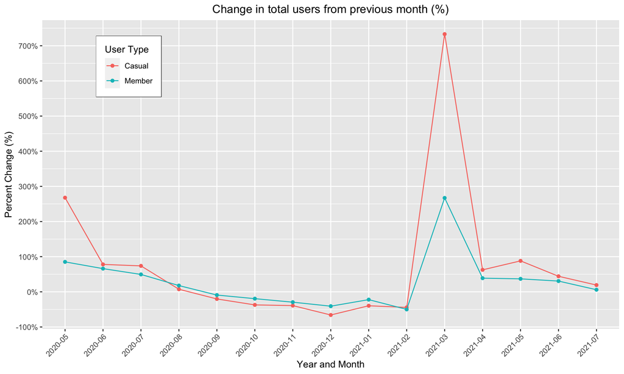

- ~740% increase and ~250% in casual users and members, respectively, from Feb 2021 to March 2021.

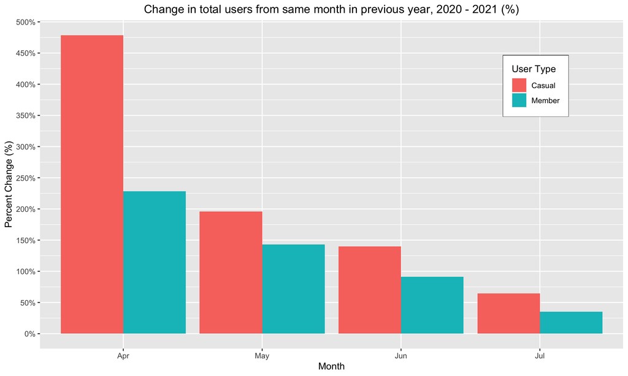

### 3.3.2 Then, we examine when the most popular times of the day occur across the week

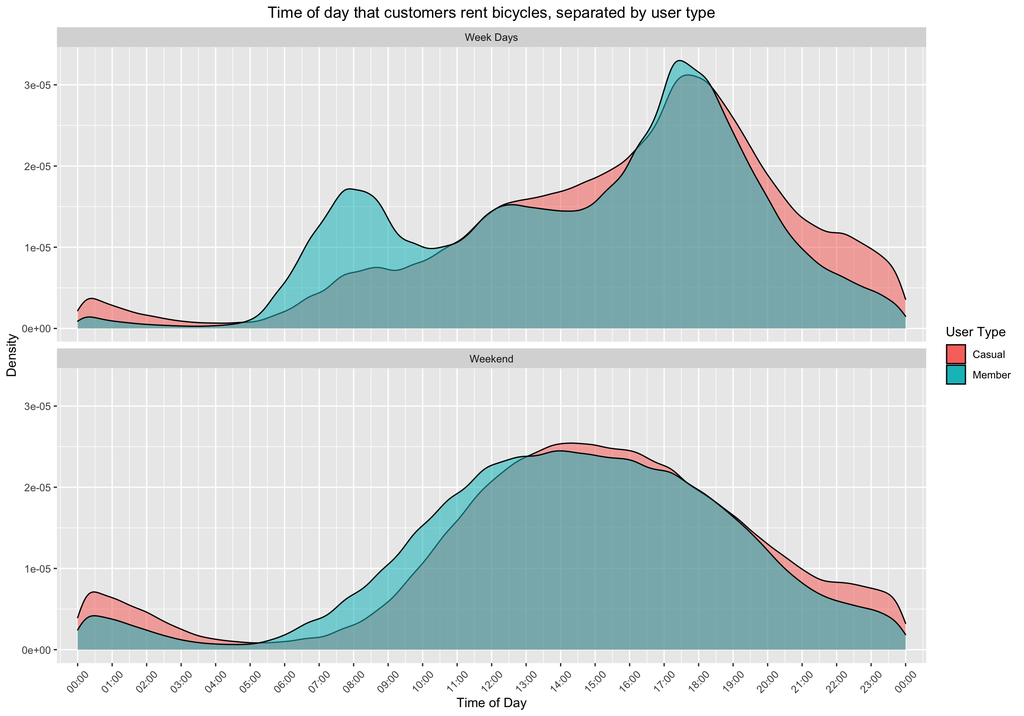

#### 3.3.2.1 Key TOD takeways

- Both members and casual users follow the same general patterns of use throughout the week; however, the following generalisations may be made:
- Week Days:
- Members:  
  o From 5am to 10:30 (peaking betwen 7:30am and 8:30am) and 4:30pm to 6pm, Monday to Friday, members make more trips. This mirrors the working day.

  o Between 5:30am and 1pm, Saturday and Sunday, members are slightly more likely to make trips
- Casual users:  
  o Between 12 and 4pm, Monday to Friday, casual users are more likely to use bicycles.

  o From 18:30pm to ~ 4am, Monday to Friday casual users are more likely, particularly in the hours between 9pm and midnight.
- Weekends:

  o Both casual users and members follow the same pattern. However, member begin to use bicycles with more regularity at around 5:30am, whereas casual users begin at around 7am. Both groups of users peak at ~ 2pm and experience slight spikes of usage between 12 and 1am.

# 4 Key Conclusions

## 4.1 Members

Bicycle use is driven by members. In 2020, particularly over winter, and up until June 20201, members have driven usage of Cyclistic bicycles. They favour docked bicycles, but also are more likely to choose classic options. They travel the same distances as casual users, but use bicycles ~ 10 minutes less per trip, indicating that they are more conditioned to bicycle travel.

Member TOD patterns indicate that they use Cyclistic bicycles for travel to and from work.

## 4.3 Recommendations

1. Market discounted membership packets during summer months
2. Target marketing to those who take public transport to work.
3. Increase number of docking stations to drive use of docked bicycles.